# Spatial Annotation Screening

This vignette exemplifies how to use Spatial Annotation Screening in SPATA2. It builds on the spatial annotations created in the vignette Creating Spatial Annotations for the glioblastoma sample UKF313T.

```r
library(SPATA2)
library(tidyverse)

# exchange my/path/to with your directory
object_t313 <- loadSpataObject("my/path/to/object_UKF313T.RDS")
```

```r
# prefiltering genes for spatial variability with SPARKX is recommended
object_t313 <- runSparkx(object_t313)

sparkx_genes <- getSparkxGenes(object_t313, threshold_pval = 0.05)

necrotic_ids <- c("necrotic_area", "necrotic_edge", "necrotic_edge2")

sas_out <-
  spatialAnnotationScreening(
    object = object_t313,
    ids = necrotic_ids,
    variables = sparkx_genes,
    core = FALSE, # do not include the core of the annotations
    distance = "dte" # distance to edge
  )
```

The output of `spatialAnnotationScreening()` is an S4 object of class `SpatialAnnotationScreening` which contains the set up as well as the results from the algorithm.

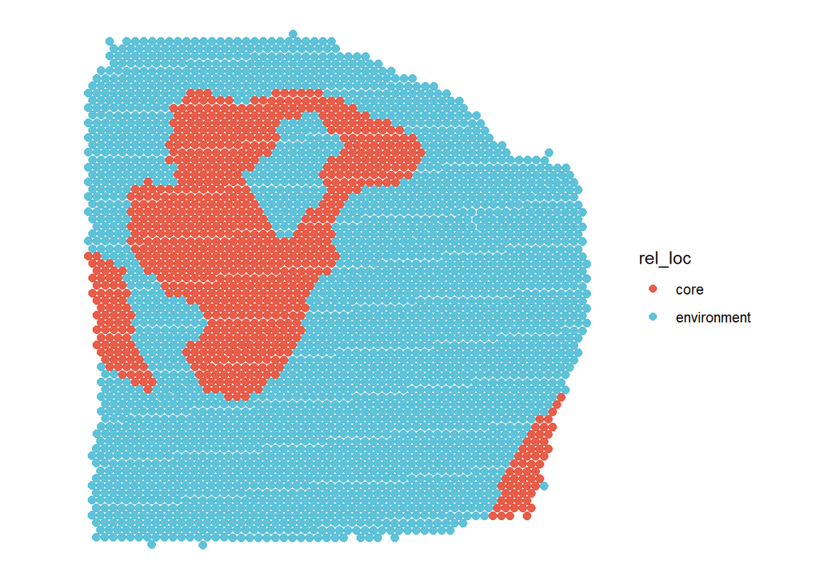

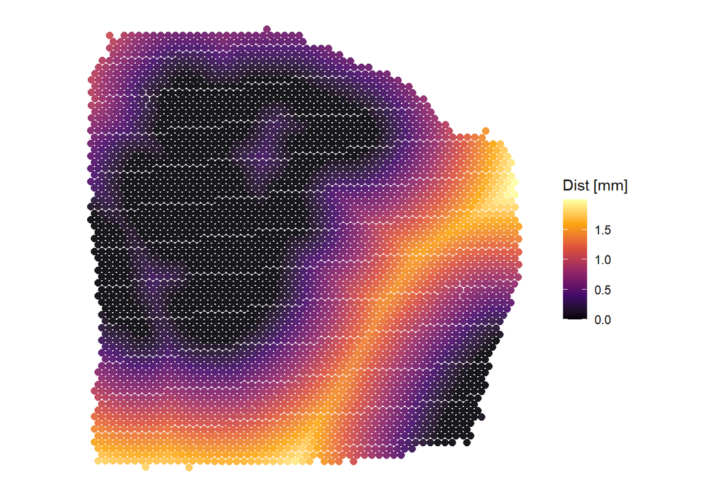

Fig.1 Recreate the screening set up.

```r
sas_areas <- color_vector(clrp = "npg", names = c("core", "environment", "periphery"))


# use the coordinates data.frame to recreate the set up
plotSurface(sas_out@coords, color_by = "rel_loc", clrp_adjust = sas_areas)
plotSurface(sas_out@coords, color_by = "dist") + labs(color = "Dist [mm]")
```

Slot @significance contains a data.frame with one row for each screened variable which provides information regarding the degree of randomness the inferred pattern contains as quantified by the total variation (*tot_var*). The p-value gives the probability to obtain such a total variation under complete randomness and indicates the degree of significance. Column *fdr* contains the adjusted p-value according to the False Discovery Rate.

```r
filter(sas_out@significance, p_value < 0.05)
```

```
## # A tibble: 547 x 6
##    variables  rel_var tot_var p_value norm_var     fdr
##    <chr>        <dbl>   <dbl>   <dbl>    <dbl>   <dbl>
##  1 A2M          0.112    2.40  0.0129   0.120  0.0708
##  2 AC245595.1   1        2.33  0.0083   0.117  0.0509
##  3 ACTA2        0.515    2.15  0.0036   0.108  0.0308
##  4 ACTB         0.882    1.74  0        0.0868 0
##  5 ACTG1       -0.563    1.80  0.0002   0.0899 0.00379
##  6 ADAM12       0.358    2.46  0.0157   0.123  0.0753
##  7 ADD1        -0.491    2.40  0.0129   0.120  0.0708
##  8 ADM         -0.959    1.74  0        0.0871 0
##  9 ADRM1        0.914    2.68  0.0338   0.134  0.120
## 10 AKR1B1       1        2.28  0.0065   0.114  0.0437
## # i 537 more rows
```

Slot @results contains the model fitting results. It is a data.frame where each row corresponds to a variable ~ model pair. The columns *mae* (mean absolute error) and *rmse* (root mean squared error) indicate the quality of the fit. The lower the value the better.

```r
filter(sas_out@results, rmse < 0.2)
```

```
## # A tibble: 292 x 5
##    variables models                corr    mae   rmse
##    <chr>     <chr>                <dbl>  <dbl>  <dbl>
##  1 ACTA2     immediate_ascending  0.892 0.0681 0.124
##  2 ACTB      immediate_ascending  0.953 0.0688 0.0892
##  3 ADM       immediate_descending 0.962 0.0652 0.0843
##  4 AKR1B1    late_ascending       0.849 0.138  0.166
##  5 ANAPC11   immediate_ascending  0.939 0.156  0.180
##  6 ANAPC11   linear_ascending     0.935 0.0967 0.120
##  7 ANGPTL4   immediate_descending 0.941 0.134  0.161
##  8 ANGPTL4   linear_descending    0.861 0.137  0.171
##  9 APOC1     late_ascending       0.937 0.136  0.163
## 10 APOC1     linear_ascending     0.950 0.0983 0.126
## # i 282 more rows
```

You can filter the results for significant variables below a certain threshold for a specific model to obtain genes of potential interest.

```r
sign_genes <- filter(sas_out@significance, fdr < 0.05)[["variables"]]

desc_genes <-
  # filter for significance
  filter(.data = sas_out@results, variables %in% {{sign_genes}}) %>%
  # filter for specific models
  filter(str_detect(models, pattern = "descending") & rmse < 0.2) %>%
  pull(variables) %>%
  unique()

asc_genes <-
  # filter for significance
  filter(.data = sas_out@results, variables %in% {{sign_genes}}) %>%
  # filter for specific models
  filter(str_detect(models, pattern = "ascending") & rmse < 0.2) %>%
  pull(variables) %>%
  unique()

length(desc_genes)
```

```
## [1] 60
```

```r
length(asc_genes)
```

```
## [1] 154
```

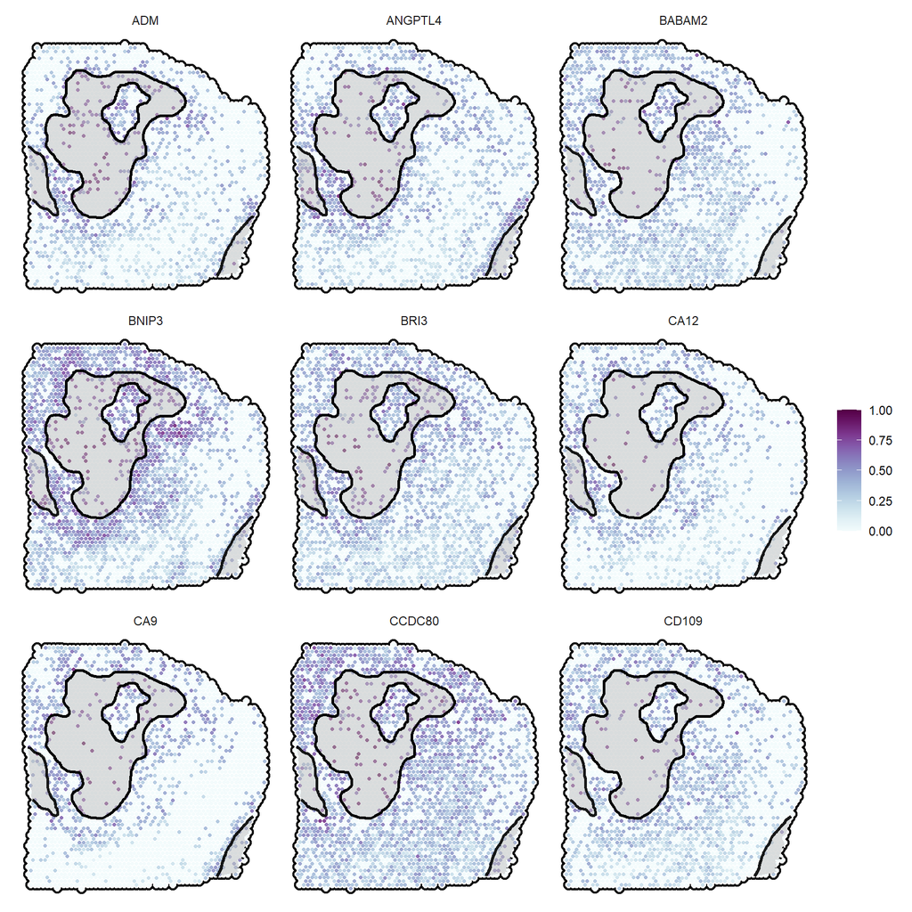

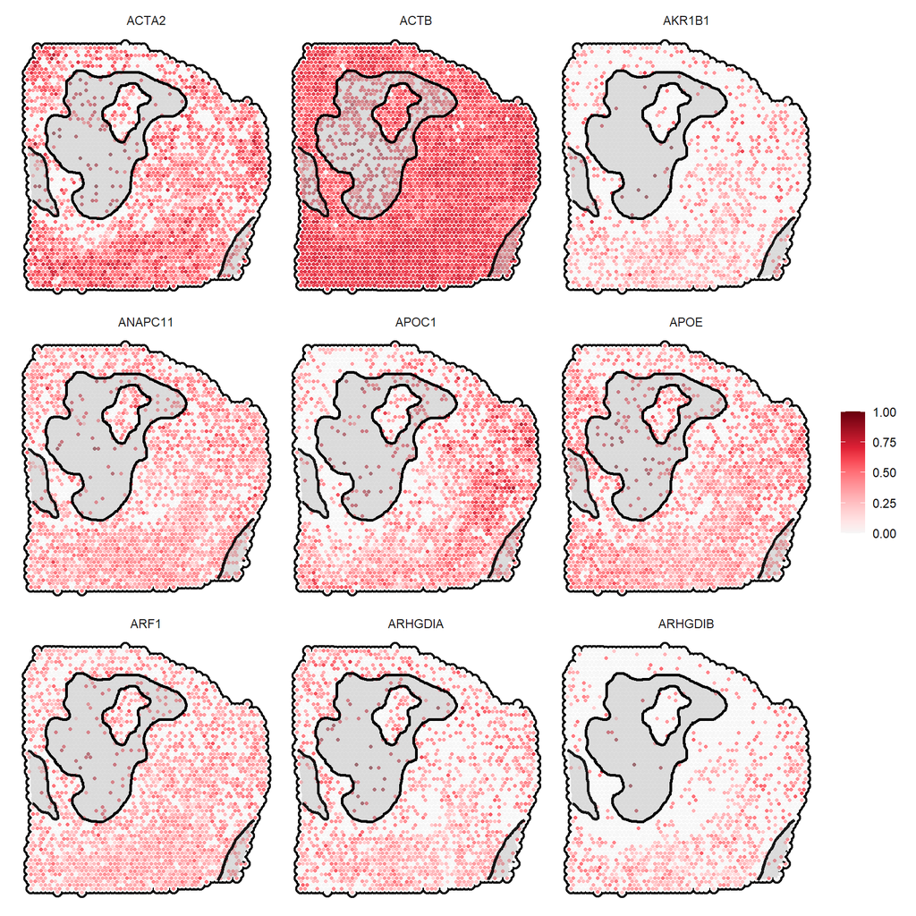

Fig.2 Extraction and visualization of screening results.

```r
plotSurfaceComparison(object_t313, color_by = desc_genes[1:9], normalize = T, outline = T, pt_clrsp = "BuPu") +
  ggpLayerSpatAnnOutline(object_t313, ids = necrotic_ids, fill = "grey", incl_edge = T)

plotSurfaceComparison(object_t313, color_by = asc_genes[1:9], normalize = T, outline = T, pt_clrsp = "Reds 3") +
  ggpLayerSpatAnnOutline(object_t313, ids = necrotic_ids, fill = "grey", incl_edge = T)
```